# Grover's Search Algorithm

writer : ericedu1

date : 230705

## 1 Symmetric transposition in Hilbert space

Suppose there is two different vector $\ket \psi,\ket\phi\in H$. Let’s describe the symmetric transposition of $\ket\phi$ to $\ket\psi$. We can use graphical description like this.

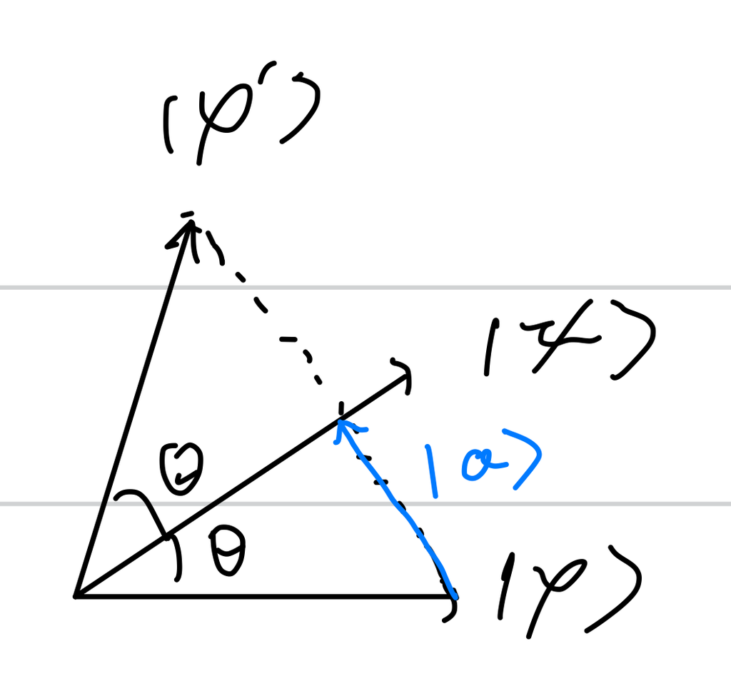

Untitled

$$\ket\alpha=\bra\psi\phi\rangle\ket\psi-\ket\phi$$

So,

$$\begin{align*}
\ket{\phi'}&=2\ket\alpha+\ket\phi\\
&=(2\ket\psi\bra\psi-I)\ket\phi\equiv G\ket\phi
\end{align*}$$

Check if G is unitary.

$$\begin{align*}
G^\dagger G&=GG^\dagger\\
&=4\ket\psi\bra\psi-2\ket\psi\bra\psi-2\ket\psi\bra\psi+I=I
\end{align*}$$

Therefore, symmetric transposition operator G is unitary. When we transpose $\ket\psi$ by axis of $\ket x$, let’s just say $\ket{\psi'}=G_x\ket\psi$

## 2 Search Problem

Search Problem is that for $N$ possible answer, find $M$ answer we want. For the space build by n bit, possible answer could be $N=2^n$. When we say the index of element in possible answer space as $x$ and for quantum computer $\ket x$, the superposition of all possible answers can be implemented as following description.

$$H^{\otimes n}\ket 0^{\otimes n}=\frac1{\sqrt 2^n}\sum_x\ket x$$

From now on, $\ket\psi=H^{\otimes n}\ket 0^{\otimes n}$. We say that there is $M$ answer, so if we let $\ket \alpha$ as incorrect vector’s superposition and $\ket\beta$as correct vector’s it, then we can change our vector as $\ket\psi$ as under.

$$\begin{align*}
&\ket\psi=\sqrt\frac {N-M} N\ket\alpha+\sqrt\frac{M}{N}\ket\beta\\
&when,\ket\alpha=\frac1{\sqrt M}\sum_{x'}\ket
x,\ket\beta=\frac1{\sqrt{ N-M}}\sum_{x"}\ket x
\end{align*}$$

We can check that $\bra\alpha\beta\rangle=0$ easily. Now, all we need to do is change our $\ket \psi$ to $\ket\beta$.

## 3 The algorithm

As $\ket \alpha\&\ket\beta$ is orthogonal and $\ket\psi$ is super position of two vector, we can draw this vector space.

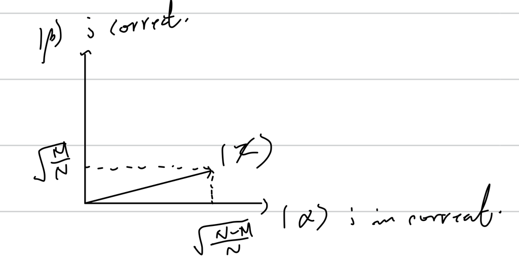

Untitled

Let’s use symmetric transposition to push our $\ket\psi$ to $\ket\beta$. The pushing process is described below.

1. ready $\ket\psi$
2. add $G_\alpha$, $\ket{\psi'}=G_\alpha\ket\psi$.
3. add $G_\psi$, $\ket{\psi''}=G_\psi G_\alpha\ket\psi$.
4. repeat 2,3

The process 1,2,3 can be described in graphic below.

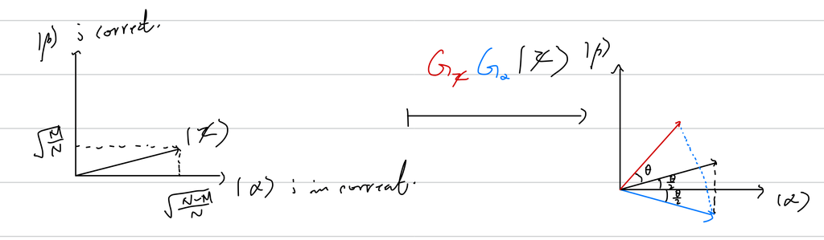

Untitled

How many times do we need to repeat the process? When we let $G_\psi G_\alpha=G$ and check the angle of k times repeated state $G^k\ket\psi$, it will follow this description.

$$G^k\ket\psi=cos(\frac{2k+1}{2}\theta)\ket\alpha+sin(\frac{2k+1}{2}\theta)\ket\beta$$

By $cos\frac\theta 2=\sqrt{\frac{N-M}{N}},sin\frac\theta 2=\sqrt{\frac MN}$, $sin\theta=\frac{2\sqrt{M(N-M)}}{N}$. Therefore $\theta=arcsin\frac{2\sqrt{M(N-M)}}{N}$. And we can intuitively know that when we iterate k times that follows the eqation $\frac{2k+1}2\theta=\frac\pi 2$, our circuit can get $\ket \beta$in high probability. So know we can calculate how many times do we need to interate.

$$I=\frac\pi{2\theta}-\frac12=\frac\pi{2arcsin(2\frac{\sqrt{M(N-M)}}{N})}-\frac12$$

When $M<<N$, $\frac\theta2\sim\sqrt{\frac{M}{N}}$. So we can get that the complexity of the algorithm we found(Grover’s Algorithm) is $O(\sqrt{\frac NM})$.

## 4 Discussion

We construct our algorithm on the situation that we knows what $\ket\alpha$ is. On the normal situation, we don’t know what it could be. So, we need to change our $G$’s $G_\alpha$ part. It will be replaced to Oracle which can represent almost every problem we need to solve.

## 5 Oracle

For normalizing our problem, we need to change $G_\alpha$. We will build new operation $O$. Operator $O$ will act on the state $\ket x\ket q$ which $x$ will be the index part, and $\ket q$ will be the *Oracle qubit*. Define new function $x$ as when $x$ is in correct answer $f(x)=1$, if not $f(x)=0$. Oracle $O$ acts on qubit like followings.

$$O\ket x\ket q=\ket x\ket{q+f(x)}$$

We need to remind that our $O$ acts like $G_\alpha$. Let’s check what $G_\alpha$ does.

$$G_\alpha\ket\psi=G_\alpha(\alpha\ket\alpha+\beta\ket\beta)=\alpha\ket\alpha-\beta\ket\beta$$

We want when $x$ is correct answer, $O\ket x\ket q=-\ket x\ket q$. It means that $\ket {q+1}=-\ket q$. It is satisfied when our $\ket q=\frac1{\sqrt 2}(\ket 0-\ket 1)$. Then our state will be like this.

$$O\ket x\ket q=(-1)^{f(x)}\ket x\ket q$$

## 6 Grover’s Algorithm

Our search algorithm will follow this steps.

**Inputs:** Oracle $O$ for the given problem, n+1 qubits in $\ket 0$.

1. Add $H^{\otimes n}$to first $n$ qubits and add $HX$ to last qubit. → $\sum_x\ket x\ket q=\ket\psi\ket q$
2. Add $O$
3. Add $G_\psi$
4. repeat 2,3
5. Measure state

**Outputs:** $x_0$, our target data.

reference. Quantum Computation and Quantum Information, Nielson&chuang

To main page